# Matplotlib

```python
import pandas as pd
import numpy as np
```

```python
import matplotlib.pyplot as plt
```

```python
sonlar = np.arange(10)
sonlar
```

```
array([0, 1, 2, 3, 4, 5, 6, 7, 8, 9])
```

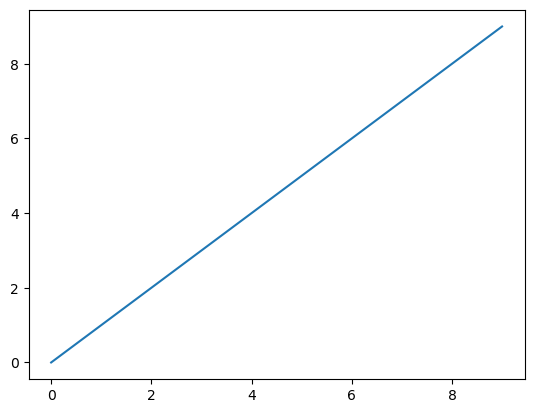

```python
plt.plot(sonlar)
```

#### ! y ning qiymati berilmadi. u holatda avtomatik tarzda y=x qabul qilinadi.

[<matplotlib.lines.Line2D at 0x240264eac10>] bu matn plt.show() ni yozilmaganda kelib chiqadi

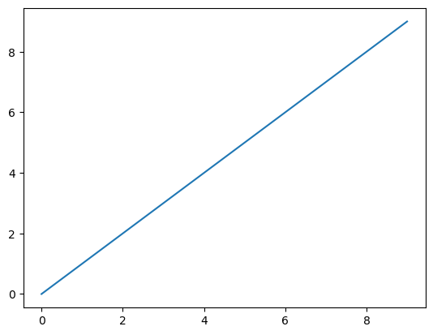

```python
plt.plot(sonlar)
plt.show()
```

Plot - (ingl) chizma, chizish

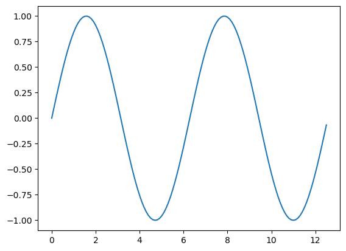

```python
x = np.arange(0, 4 * np.pi, 0.1)
y = np.sin(x)

plt.plot(x, y)
plt.show()
```

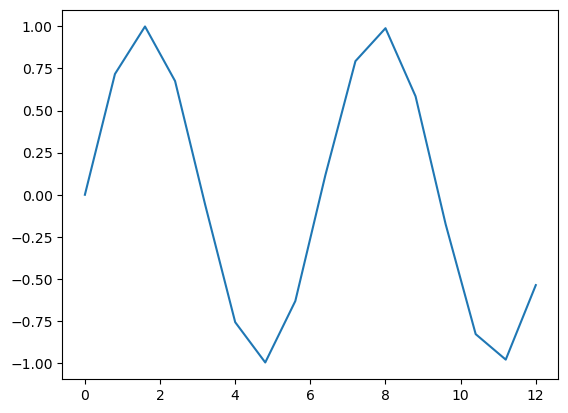

```python
x = np.arange(0, 4 * np.pi, 0.8)
y = np.sin(x)

plt.plot(x, y)
plt.show()
```

```python
x = np.arange(0, 4 * np.pi, 0.1)
y = np.sin(x)
```

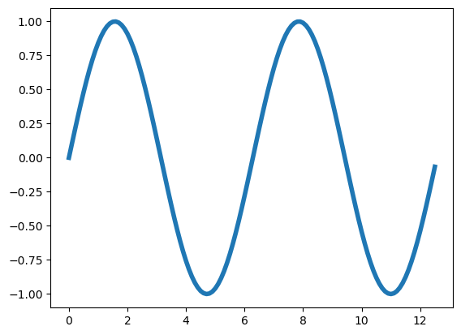

```python
plt.plot(x, y, linewidth = 4)
plt.show()
```

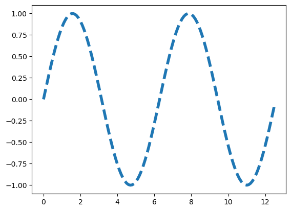

```python
x = np.arange(0, 4 * np.pi, 0.1)
y = np.sin(x)

plt.plot(x, y, linewidth = 4, linestyle = "dashed")
plt.show()
```

# **Matplotlib `linestyle` turlari**

| `linestyle` qiymati | Qisqa shakli | Ko‘rinishi | Izoh |
| --- | --- | --- | --- |
| `"solid"` | `"-"` | ────────── | Oddiy uzluksiz chiziq (default) |
| `"dashed"` | `"--"` | -- -- -- -- | Uzlukli chiziq |
| `"dashdot"` | `"-."` | ─·─·─·─ | Chiziq + nuqta aralash |
| `"dotted"` | `":"` | ·········· | Nuqtali chiziq |
| `"None"` | `""` | (chiziq yo‘q) | Chiziq chizilmaydi, faqat marker bo‘lishi mumkin |

# **Qo‘shimcha ixtiyoriy style lar (tuple orqali)**

Matplotlib chiziq uslubini to‘liq nazorat qilish uchun **pattern tuple** ham ishlaydi:

Misol:

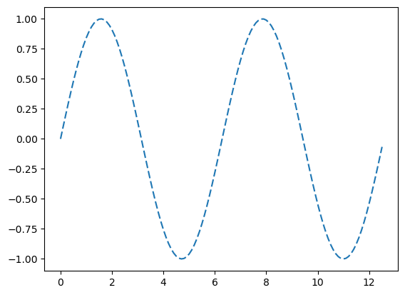

```python
plt.plot(x, y, linestyle=(0, (5, 2)))
plt.show()
```

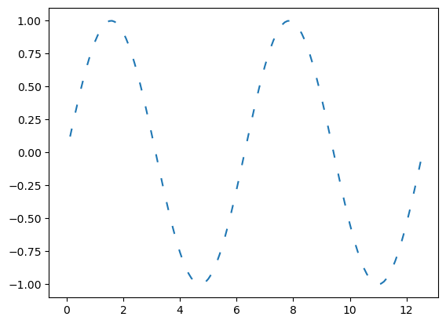

```python
plt.plot(x, y, linestyle=(50, (5, 10)))
plt.show()
```

Bu quyidagini anglatadi:

| Tuple | Ma’nosi |
| --- | --- |
| `(offset, (dash_length, gap_length))` | Maxsus uzlukli chiziq yaratadi |

# **Eng ko‘p ishlatiladigan variantlar**

```
plt.plot(x, y, linestyle="-")    # uzluksiz
plt.plot(x, y, linestyle="--")   # uzlukli
plt.plot(x, y, linestyle=":")    # nuqtali
plt.plot(x, y, linestyle="-.")   # chiziq-nuqta
```

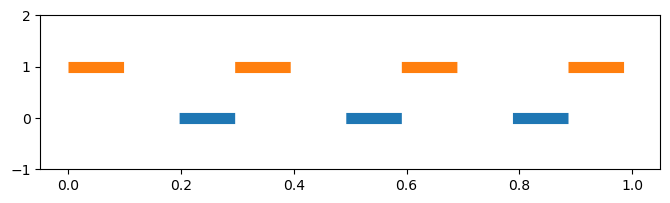

```python
x = np.array([0, 1])
y = np.array([0, 0])

plt.figure(figsize=(8, 2))

plt.plot(x, y, linewidth=8, linestyle=(50, (5, 10)))
plt.plot(x, y+1, linewidth=8, linestyle=(0, (5, 10)))

plt.ylim(-1, 2)
plt.show()
```

# 1️⃣ **`plt.figure(figsize=(8, 2))`**

Bu — chiziladigan grafik oynasining **umumiy o‘lchamini** belgilaydi.

- `figsize=(8, 2)` → (kenglik = 8 dyuym, balandlik = 2 dyuym)

Demak, figura juda **keng**, lekin **past bo‘yli** qilib yaratiladi.

Odatda chiziqlarni yaqqol ko‘rsatish, offset farqini ko‘rish yoki banner ko‘rinishidagi grafika uchun ishlatiladi.

# 2️⃣ **`plt.ylim(-1, 2)`**

Bu — **y-o‘qi** uchun ko‘rinadigan diapazonni belgilaydi:

- Pastki qiymat = **-1**
- Yuqori qiymat = **2**

Ya’ni grafikda `y` o‘qi faqat -1 dan 2 gacha bo‘lgan qismni ko‘rsatadi.

Buning maqsadi — grafikni vertikal bo‘yicha “tor” ko‘rinishda ushlab turish, chiziqlarni yaqin qilib ko‘rsatish.

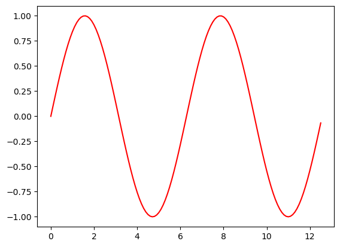

```python
plt.plot(x, y, color="red")
plt.show()
```

# **1. Rang nomlari (CSS-style English color names)**

Matplotlib 140+ ta CSS ranglarni qo‘llaydi. Eng ko‘p ishlatiladiganlari:

| Rang nomi (EN) | Rang nomi (UZ) |
| --- | --- |
| `"black"` | qora |
| `"white"` | oq |
| `"red"` | qizil |
| `"green"` | yashil |
| `"blue"` | ko‘k |
| `"yellow"` | sariq |
| `"cyan"` | ko‘k-yashil (sian) |
| `"magenta"` | to‘q pushti / magenta |
| `"orange"` | to‘q sariq / olovrang |
| `"purple"` | binafsha |
| `"brown"` | jigarrang |
| `"pink"` | pushti |
| `"gray"` / `"grey"` | kulrang |
| `"lime"` | och yashil / laym rang |
| `"navy"` | to‘q ko‘k |
| `"gold"` | oltinrang |
| `"teal"` | malla-ko‘k / to‘q cyan |
| `"olive"` | zaytunn rang (olive) |

# **2. Qisqa rang kodlari (single-letter codes)**

Matplotlib klassik qisqa belgilarni ham qabul qiladi:

| Kod | Rang |
| --- | --- |
| `'b'` | blue |
| `'g'` | green |
| `'r'` | red |
| `'c'` | cyan |
| `'m'` | magenta |
| `'y'` | yellow |
| `'k'` | black |
| `'w'` | white |

# **3. HEX rang kodlari (web style)**

| Format | Misol |
| --- | --- |
| `"#RRGGBB"` | `"#FF0000"` (qizil) |
| `"#RGB"` | `"#0F0"` (yashil) |
| `"#RRGGBBAA"` | `"#FF000080"` (yarim shaffof qizil) |

# **4. RGB va RGBA qiymatlari (0–1 oralig‘ida)**

| Format | Misol | Ma’nosi |
| --- | --- | --- |
| `(R, G, B)` | `(1, 0, 0)` | qizil |
| `(R, G, B, A)` | `(0, 0, 1, 0.5)` | yarim shaffof ko‘k |

Ya’ni har bir qiymat **0 dan 1 gacha** bo‘ladi.

# **5. 0–255 oralig‘idagi RGB (Numpy array orqali)**

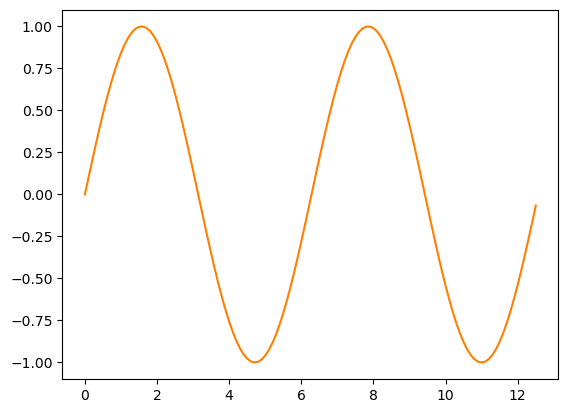

```python
color = np.array([255, 128, 0]) / 255
plt.plot(x, y, color=color)
plt.show()
```

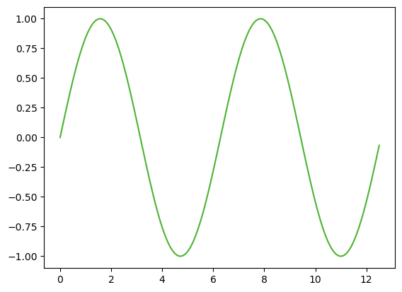

```python
plt.plot(x, y, color=(0.3, 0.7, 0.2))
plt.show()
```

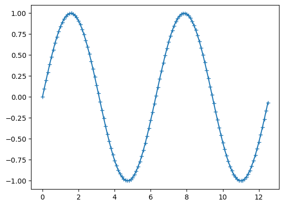

```python
plt.plot(x, y, marker="+")
plt.show()
```

Quyida **Matplotlib `marker`** parametrining barcha asosiy va keng qo‘llaniladigan **marker turlari** to‘liq ro‘yxatda keltirilgan.

## 🔵 **1. Nuqta va oddiy markerlar**

| Marker | Tavsifi |
| --- | --- |
| `"."` | kichik nuqta (point) |
| `","` | juda kichik nuqta (pixel) |
| `"o"` | doira (circle) |
| `"v"` | pastga qaragan uchburchak |
| `"^"` | yuqoriga qaragan uchburchak |
| `"<"` | chapga qaragan uchburchak |
| `">"` | o‘ngga qaragan uchburchak |
| `"1"` | pastga yulduzsimon marker |
| `"2"` | yuqoriga yulduzsimon marker |
| `"3"` | chapga yulduzsimon marker |
| `"4"` | o‘ngga yulduzsimon marker |

## 🔶 **2. Kvadrat, romb va ko‘p burchakli markerlar**

| Marker | Tavsifi |
| --- | --- |
| `"s"` | kvadrat (square) |
| `"p"` | pentagon (5 burchak) |
| `"P"` | to‘ldirilgan plus belgisi |
| `"*"` | yulduz (*) |
| `"h"` | geksagon 1 (6 burchak) |
| `"H"` | geksagon 2 (6 burchak) |
| `"D"` | katta romb (diamond) |
| `"d"` | kichik romb |

## 🟥 **3. Chiziq ko‘rinishidagi markerlar**

[output not shown]

## ➕ **4. Plus/minus markerlar**

| Marker | Tavsifi |
| --- | --- |
| `"+"` | plus belgisi |
| `"x"` | x belgisi (kichik) |
| `"X"` | katta x belgisi |

## 🔲 **5. Yo‘nalishli belgi markerlari**

| Marker | Tavsifi |
| --- | --- |
| `"8"` | sakkiz shakli |
| `"None"` / `None` | marker yo‘q |
| `" "` (bo‘sh) | marker yo‘q |
| `""` | marker yo‘q |

## 🟣 **6. LaTeX/Math markerlar (`$...$`)**

Har qanday bitta belgini **math text** ko‘rinishida marker sifatida ishlatish mumkin:

| Marker | Tavsifi |
| --- | --- |
| `"$a$"` | “a” harfi |
| `"$\pi$"` | pi belgisi |
| `"$\omega$"` | omega belgisi |
| `"$*$"` | yulduz |
| `"$\heartsuit$"` | yurakcha |

Bu juda moslashuvchan — istalgan matematik belgini marker qilish mumkin.

# Eng ko‘p ishlatiladigan markerlar (eslab qolish oson)

```
"."   # point
"o"   # circle
"^"   # triangle_up
"s"   # square
"*"   # star
"x"   # x mark
"D"   # diamond
"p"   # pentagon
"v"   # triangle_down
"+"   # plus
```

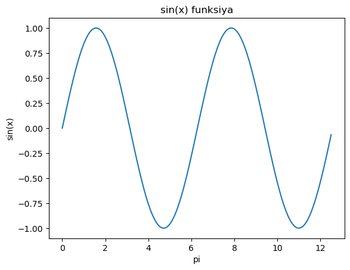

```python
plt.plot(x, y)
plt.title("sin(x) funksiya")
plt.xlabel("pi")
plt.ylabel('sin(x)')
plt.show()
```

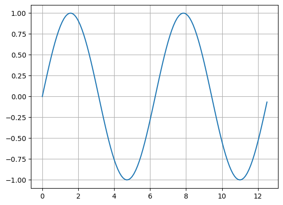

```python
plt.plot(x, y)

plt.grid()

plt.show()
```

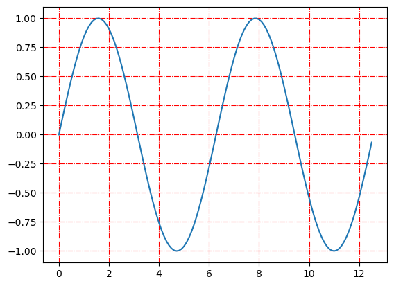

```python
plt.plot(x, y)

plt.grid(color = 'r', linestyle = "-.")

plt.show()
```

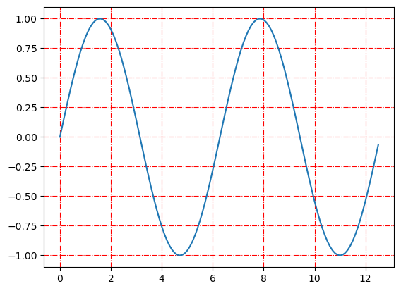

```python
plt.plot(x, y)

plt.grid(color = 'r', linestyle = "-.")
plt.figure(figsize = (10, 4))
plt.show()
```

## ! `plt.figure(figsize = (10, 4))` ni boshiga yozish kerak

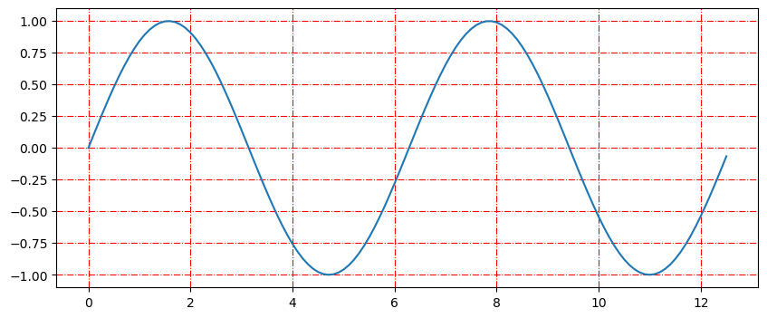

```python
plt.figure(figsize = (10, 4))
plt.plot(x, y)

plt.grid(color = 'r', linestyle = "-.")

plt.show()
```

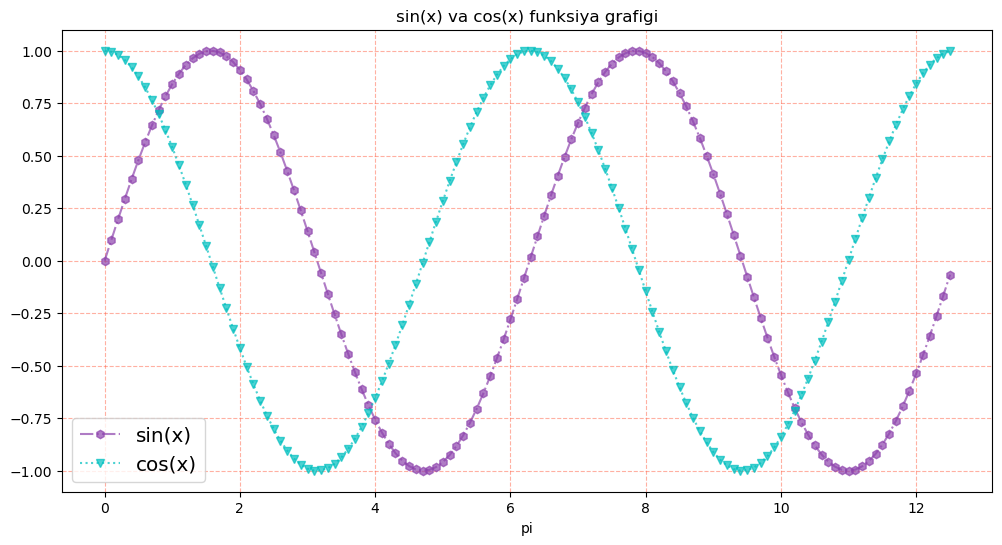

```python
x = np.arange(0, 4 * np.pi, 0.1)
sin = np.sin(x) # sin(x)
cos = np.cos(x) # cos(x)

plt.figure(figsize=(12,6))
# sin(x) grafigi
plt.plot(x, sin,
         linewidth=1.5,
         linestyle='-.',
         color='#8E44AD',
         alpha=0.7,
         marker='h')

# cos(x) grafigi
plt.plot(x, cos,
         linewidth=1.5,
         linestyle=':',
         color='c',
         alpha=0.7,
         marker='v')

# Grafik nomi:
plt.title('sin(x) va cos(x) funksiya grafigi')
# x-o'q nomi:
plt.xlabel("pi")

# Har bir chiziq haqida ma'lumot:
plt.legend(['sin(x)','cos(x)'], loc=0, fontsize='x-large')

plt.grid(color='tomato', alpha=0.5, linestyle='--') # setkani o'zgartirish
plt.show()
```

`alpha=0.7` — bu **shaffoflik (opacity)** darajasini belgilovchi parametr.

- `alpha` **0 dan 1 gacha** qiymat qabul qiladi.
- 0 → to‘liq shaffof (ko‘rinmaydi)
- 1 → to‘liq qattiq (shaffof emas)

# Misol

```
plt.plot(x, y, color='red', alpha=0.7)
```

Bu chiziq ochroq qizil bo‘lib ko‘rinadi.

Quyida **`plt.legend()`** funksiyasining **asosiy va eng ko‘p ishlatiladigan parametrlarini** sodda, aniq va tartibli qilib tushuntirib beraman.

# **`plt.legend()` asosiy parametrlari**

| Parametr | Ma’nosi | Misol |
| --- | --- | --- |
| **`labels`** | Legenddagi yozuvlar ro‘yxati | `plt.legend(['sin', 'cos'])` |
| **`loc`** | Legendning joylashuvi | `loc='upper right'` yoki `loc=0` |
| **`fontsize`** | Legend matn o‘lchami | `fontsize='x-large'` yoki `fontsize=12` |
| **`title`** | Legend sarlavhasi | `title='Functions'` |
| **`title_fontsize`** | Sarlavha shrift o‘lchami | `title_fontsize=14` |
| **`frameon`** | Ramka bor/yo‘qligi | `frameon=False` |
| **`shadow`** | Soya qo‘shish | `shadow=True` |
| **`facecolor`** | Legend fon rangi | `facecolor='lightgray'` |
| **`edgecolor`** | Ramka rangi | `edgecolor='black'` |
| **`bbox_to_anchor`** | Legendni grafik tashqarisiga joylashtirish | `bbox_to_anchor=(1,1)` |
| **`ncol`** | Ustunlar soni | `ncol=2` (legendni 2 ustun qilish) |
| **`markerfirst`** | Marker chapda/ongda | `markerfirst=False` |
| **`handlelength`** | Marker chizig‘i uzunligi | `handlelength=4` |
| **`handletextpad`** | Marker va matn oralig‘i | `handletextpad=1.0` |
| **`borderpad`** | Ichki bo‘shliq | `borderpad=0.5` |
| **`labelspacing`** | Yozuvlar orasidagi vertikal masofa | `labelspacing=1.2` |

# **Eng ko‘p ishlatiladigan `loc` qiymatlari**

Loc — legend joylashuvi:

| Qiymat | Tavsif |
| --- | --- |
| `0` | Best (Matplotlib o‘zi eng yaxshi joyni tanlaydi) |
| `1` | Upper right |
| `2` | Upper left |
| `3` | Lower left |
| `4` | Lower right |
| `5` | Right |
| `6` | Center left |
| `7` | Center right |
| `8` | Lower center |
| `9` | Upper center |
| `10` | Center |

`fontsize` parametrida **2 xil format** ishlatiladi:

Quyida ikkalasining to‘liq ro‘yxati berilgan.

# 🅰️ **1. Matnli (nomli) fontsize turlari — to‘liq ro‘yxat**

| Qiymat | Ma’nosi |
| --- | --- |
| `'xx-small'` | juda-juda kichik |
| `'x-small'` | juda kichik |
| `'small'` | kichik |
| `'medium'` | o‘rta (standart) |
| `'large'` | katta |
| `'x-large'` | juda katta |
| `'xx-large'` | juda-juda katta |

Bular matplotlib’ning default tayyor o‘lchamlari.

# 🔢 **2. Raqamli fontsize (aniq raqam berish)**

`fontsize=12` `fontsize=20` `fontsize=32`

→ bu holda qiymat **point (pt)** o‘lchov birligida bo‘ladi.

Masalan:

```
plt.title("Grafik", fontsize=18)
plt.xlabel("x", fontsize=14)
plt.ylabel("y", fontsize=14)
plt.legend(fontsize=12)
```

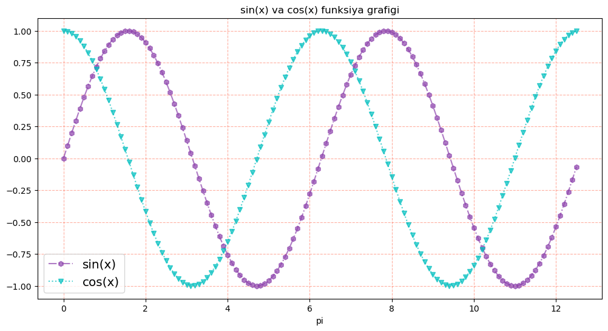

```python
x = np.arange(0, 4 * np.pi, 0.1)
sin = np.sin(x) # sin(x)
cos = np.cos(x) # cos(x)

plt.figure(figsize=(12,6))
# sin(x) grafigi
plt.plot(x, sin,
         linewidth=1.5,
         linestyle='-.',
         color='#8E44AD',
         alpha=0.7,
         marker='h')

# cos(x) grafigi
plt.plot(x, cos,
         linewidth=1.5,
         linestyle=':',
         color='c',
         alpha=0.7,
         marker='v')

# Grafik nomi:
plt.title('sin(x) va cos(x) funksiya grafigi')
# x-o'q nomi:
plt.xlabel("pi")

# Har bir chiziq haqida ma'lumot:
plt.legend(['sin(x)','cos(x)'], loc=0, fontsize='x-large')

plt.grid(color='tomato', alpha=0.5, linestyle='--') # setkani o'zgartirish
plt.savefig('sin-cos-grafik.png')
```

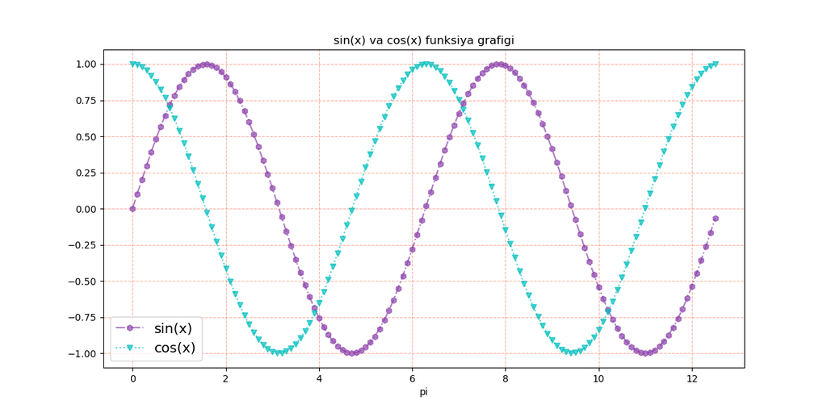

```python
from IPython.display import Image
Image('sin-cos-grafik.png')
```

Quyida **Matplotlib (plt) ning eng asosiy va eng ko‘p ishlatiladigan metodlari**, ularning **vazifalari** va **asosiy parametrlari** keltirilgan.

# **Matplotlibning eng asosiy metodlari**

| Metod | Vazifasi | Eng muhim parametrlari |
| --- | --- | --- |
| **plt.plot()** | Chiziqli grafik chizish | `x`, `y`, `color`, `linewidth`, `linestyle`, `marker`, `alpha`, `label` |
| **plt.scatter()** | Nuqtali grafik (scatter plot) | `x`, `y`, `s` (size), `c` (color), `alpha`, `marker`, `edgecolors`, `label` |
| **plt.bar()** | Ustunli diagramma (vertical bar chart) | `x`, `height`, `width`, `color`, `alpha`, `label` |
| **plt.barh()** | Gorizontal ustunli diagramma | `y`, `width`, `color`, `alpha`, `label` |
| **plt.hist()** | Histogram qurish | `x`, `bins`, `color`, `edgecolor`, `alpha`, `density` |
| **plt.boxplot()** | Boxplot (taqsimotni ko‘rsatish) | `x`, `patch_artist`, `labels`, `vert` |
| **plt.pie()** | Aylanma diagramma | `x`, `labels`, `colors`, `autopct`, `explode`, `shadow`, `startangle` |
| **plt.imshow()** | Rasm/matritsa ko‘rsatish | `cmap`, `interpolation`, `vmin/vmax` |
| **plt.fill_between()** | Y o‘qi bo‘yicha hududni bo‘yash | `x`, `y1`, `y2`, `alpha`, `color` |
| **plt.title()** | Grafik nomi qo‘yish | `label`, `fontsize`, `color`, `loc` |
| **plt.xlabel()** | X-o‘q nomi | `label`, `fontsize` |
| **plt.ylabel()** | Y-o‘q nomi | `label`, `fontsize` |
| **plt.xlim()** | X-o‘qi chegarasi | `left`, `right` |
| **plt.ylim()** | Y-o‘qi chegarasi | `bottom`, `top` |
| **plt.xticks()** | X-o‘qdagi belgilashlar | `ticks`, `labels`, `rotation` |
| **plt.yticks()** | Y-o‘qdagi belgilashlar | `ticks`, `labels`, `rotation` |
| **plt.legend()** | Izoh (legend) chiqarish | `labels`, `loc`, `fontsize`, `title`, `frameon` |
| **plt.figure()** | Yangi figura yaratish | `figsize`, `dpi`, `facecolor` |
| **plt.subplot()** | Bir figurada bir nechta grafik joylashtirish | `nrows`, `ncols`, `index` |
| **plt.subplots()** | Katta figurada subplots yaratish (eng zamonaviy) | `nrows`, `ncols`, `figsize` |
| **plt.grid()** | Tarmoq chiziqlari qo‘shish | `color`, `linestyle`, `linewidth`, `alpha` |
| **plt.savefig()** | Grafikni faylga saqlash | `filename`, `dpi`, `bbox_inches`, `transparent` |
| **plt.show()** | Grafikni ekranga chiqarish | — |